# D2SC ICMA Notebook

Maanav Choudhary

2024-12-02

# ICMA Sept 9 2024

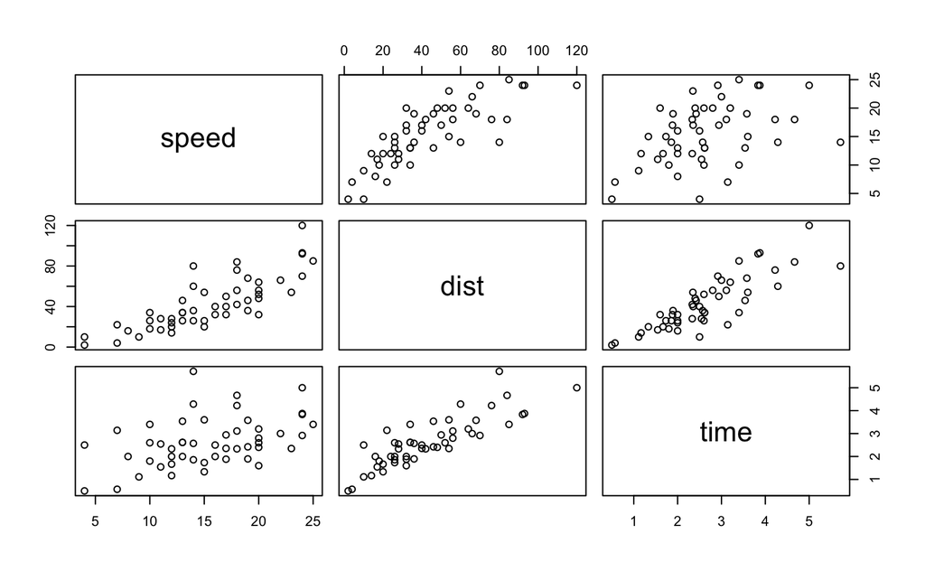

# ICMA Sept 11 2024

```
[1] 4
```

Value gets saved in environment

```
[1] 2
```

```
[1] 0.5
```

```
[1] "/Users/emperormaanav/Documents/COGSCI412inR/ICMA"
```

# ICMA Sept 16 2024

```
Error in head.default(3, billboard) :
  invalid 'n' - must be numeric, possibly NA.
```

| artist | track | date.entered | wk1 | wk2 | wk3 | wk4 | wk5 | wk6 | wk7 | wk8 | wk9 | wk10 | wk11 | wk12 | wk13 | wk14 | wk15 | wk16 | wk17 | wk18 | wk19 | wk20 | wk21 | wk22 | wk23 | wk24 | wk25 | wk26 | wk27 | … |
| --- | --- | --- | --- | --- | --- | --- | --- | --- | --- | --- | --- | --- | --- | --- | --- | --- | --- | --- | --- | --- | --- | --- | --- | --- | --- | --- | --- | --- | --- | --- |
| 2 Pac | Baby Don't Cry (Keep... | 2000-02-26 | 87 | 82 | 72 | 77 | 87 | 94 | 99 | NA | NA | NA | NA | NA | NA | NA | NA | NA | NA | NA | NA | NA | NA | NA | NA | NA | NA | NA | NA | … |
| 2Ge+her | The Hardest Part Of ... | 2000-09-02 | 91 | 87 | 92 | NA | NA | NA | NA | NA | NA | NA | NA | NA | NA | NA | NA | NA | NA | NA | NA | NA | NA | NA | NA | NA | NA | NA | NA | … |
| 3 Doors Down | Kryptonite | 2000-04-08 | 81 | 70 | 68 | 67 | 66 | 57 | 54 | 53 | 51 | 51 | 51 | 51 | 47 | 44 | 38 | 28 | 22 | 18 | 18 | 14 | 12 | 7 | 6 | 6 | 6 | 5 | 5 | … |

```
[1] 5.25
```

| rowname | mpg | cyl | disp | hp | drat | wt | qsec | vs | am | gear | carb |
| --- | --- | --- | --- | --- | --- | --- | --- | --- | --- | --- | --- |
| Mazda RX4 | 21.0 | 6 | 160.0 | 110 | 3.90 | 2.620 | 16.46 | 0 | 1 | 4 | 4 |
| Mazda RX4 Wag | 21.0 | 6 | 160.0 | 110 | 3.90 | 2.875 | 17.02 | 0 | 1 | 4 | 4 |
| Datsun 710 | 22.8 | 4 | 108.0 | 93 | 3.85 | 2.320 | 18.61 | 1 | 1 | 4 | 1 |
| Hornet 4 Drive | 21.4 | 6 | 258.0 | 110 | 3.08 | 3.215 | 19.44 | 1 | 0 | 3 | 1 |
| Hornet Sportabout | 18.7 | 8 | 360.0 | 175 | 3.15 | 3.440 | 17.02 | 0 | 0 | 3 | 2 |
| Valiant | 18.1 | 6 | 225.0 | 105 | 2.76 | 3.460 | 20.22 | 1 | 0 | 3 | 1 |
| Duster 360 | 14.3 | 8 | 360.0 | 245 | 3.21 | 3.570 | 15.84 | 0 | 0 | 3 | 4 |
| Merc 240D | 24.4 | 4 | 146.7 | 62 | 3.69 | 3.190 | 20.00 | 1 | 0 | 4 | 2 |
| Merc 230 | 22.8 | 4 | 140.8 | 95 | 3.92 | 3.150 | 22.90 | 1 | 0 | 4 | 2 |
| Merc 280 | 19.2 | 6 | 167.6 | 123 | 3.92 | 3.440 | 18.30 | 1 | 0 | 4 | 4 |

[output cut: 22 more lines]

# ICMA Sept 18 2024

|  | weight |
| --- | --- |
| 1 | 42 |
| 2 | 51 |
| 3 | 59 |
| 4 | 64 |
| 5 | 76 |
| 6 | 93 |
| 7 | 106 |
| 8 | 125 |
| 9 | 149 |
| 10 | 171 |

[output cut: 568 more lines]

|  | weight | Time | Chick | Diet |
| --- | --- | --- | --- | --- |
| 1 | 42 | 0 | 1 | 1 |
| 2 | 51 | 2 | 1 | 1 |
| 3 | 59 | 4 | 1 | 1 |

| chick_id | diet | age_days | weight_gm |
| --- | --- | --- | --- |
| 18 | 1 | 0 | 39 |
| 18 | 1 | 2 | 35 |
| 16 | 1 | 0 | 41 |
| 16 | 1 | 2 | 45 |
| 16 | 1 | 4 | 49 |
| 16 | 1 | 6 | 51 |
| 16 | 1 | 8 | 57 |
| 16 | 1 | 10 | 51 |
| 16 | 1 | 12 | 54 |
| 15 | 1 | 0 | 41 |

[output cut: 568 more lines]

|  | chick_id | diet | age_days | weight_gm | session |
| --- | --- | --- | --- | --- | --- |
| 1 | 1 | 1 | 0 | 42 | 0 |
| 2 | 1 | 1 | 2 | 51 | 2 |
| 3 | 1 | 1 | 4 | 59 | 4 |
| 4 | 1 | 1 | 6 | 64 | 6 |
| 5 | 1 | 1 | 8 | 76 | 8 |
| 6 | 1 | 1 | 10 | 93 | 10 |
| 7 | 1 | 1 | 12 | 106 | 12 |
| 8 | 1 | 1 | 14 | 125 | 14 |
| 9 | 1 | 1 | 16 | 149 | 16 |
| 10 | 1 | 1 | 18 | 171 | 18 |

[output cut: 568 more lines]

|  | chick_id | diet | age_days | weight_gm | weight_lbs |
| --- | --- | --- | --- | --- | --- |
| 1 | 1 | 1 | 0 | 42 | 0.09259259 |
| 2 | 1 | 1 | 2 | 51 | 0.11243386 |
| 3 | 1 | 1 | 4 | 59 | 0.13007055 |
| 4 | 1 | 1 | 6 | 64 | 0.14109347 |
| 5 | 1 | 1 | 8 | 76 | 0.16754850 |
| 6 | 1 | 1 | 10 | 93 | 0.20502646 |
| 7 | 1 | 1 | 12 | 106 | 0.23368607 |
| 8 | 1 | 1 | 14 | 125 | 0.27557319 |
| 9 | 1 | 1 | 16 | 149 | 0.32848325 |
| 10 | 1 | 1 | 18 | 171 | 0.37698413 |

[output cut: 568 more lines]

| diet | age_days | N | mean_wgt_gm | mean_wgt_lbs |
| --- | --- | --- | --- | --- |
| 1 | 20 | 17 | 170.4118 | 0.3756873 |
| 2 | 20 | 10 | 205.6000 | 0.4532628 |
| 3 | 20 | 10 | 258.9000 | 0.5707672 |
| 4 | 20 | 9 | 233.8889 | 0.5156281 |

| diet | N | mean_wgt_gm | mean_wgt_lbs |
| --- | --- | --- | --- |
| 1 | 17 | 170.4118 | 0.3756873 |
| 2 | 10 | 205.6000 | 0.4532628 |
| 3 | 10 | 258.9000 | 0.5707672 |
| 4 | 9 | 233.8889 | 0.5156281 |

```
Rows: 32
Columns: 12
$ rowname <chr> "Mazda RX4", "Mazda RX4 Wag", "Datsun 710", "Hornet 4 Drive", "Hornet Sportabout", "Valiant", "Dust…
$ mpg     <dbl> 21.0, 21.0, 22.8, 21.4, 18.7, 18.1, 14.3, 24.4, 22.8, 19.2, 17.8, 16.4, 17.3, 15.2, 10.4, 10.4, 14.…
$ cyl     <dbl> 6, 6, 4, 6, 8, 6, 8, 4, 4, 6, 6, 8, 8, 8, 8, 8, 8, 4, 4, 4, 4, 8, 8, 8, 8, 4, 4, 4, 8, 6, 8, 4
$ disp    <dbl> 160.0, 160.0, 108.0, 258.0, 360.0, 225.0, 360.0, 146.7, 140.8, 167.6, 167.6, 275.8, 275.8, 275.8, 4…
$ hp      <dbl> 110, 110, 93, 110, 175, 105, 245, 62, 95, 123, 123, 180, 180, 180, 205, 215, 230, 66, 52, 65, 97, 1…
$ drat    <dbl> 3.90, 3.90, 3.85, 3.08, 3.15, 2.76, 3.21, 3.69, 3.92, 3.92, 3.92, 3.07, 3.07, 3.07, 2.93, 3.00, 3.2…
$ wt      <dbl> 2.620, 2.875, 2.320, 3.215, 3.440, 3.460, 3.570, 3.190, 3.150, 3.440, 3.440, 4.070, 3.730, 3.780, 5…
$ qsec    <dbl> 16.46, 17.02, 18.61, 19.44, 17.02, 20.22, 15.84, 20.00, 22.90, 18.30, 18.90, 17.40, 17.60, 18.00, 1…
$ vs      <dbl> 0, 0, 1, 1, 0, 1, 0, 1, 1, 1, 1, 0, 0, 0, 0, 0, 0, 1, 1, 1, 1, 0, 0, 0, 0, 1, 0, 1, 0, 0, 0, 1
$ am      <dbl> 1, 1, 1, 0, 0, 0, 0, 0, 0, 0, 0, 0, 0, 0, 0, 0, 0, 1, 1, 1, 0, 0, 0, 0, 0, 1, 1, 1, 1, 1, 1, 1
$ gear    <dbl> 4, 4, 4, 3, 3, 3, 3, 4, 4, 4, 4, 3, 3, 3, 3, 3, 3, 4, 4, 4, 3, 3, 3, 3, 3, 4, 5, 5, 5, 5, 5, 4
$ carb    <dbl> 4, 4, 1, 1, 2, 1, 4, 2, 2, 4, 4, 3, 3, 3, 4, 4, 4, 1, 2, 1, 1, 2, 2, 4, 2, 1, 2, 2, 4, 6, 8, 2
```

# ICMA Sept 23 2024

#pivot_longer(): requires data and the columns you want to pivot into long form

| artist | track | date.entered | wk1 | wk2 | wk3 | wk4 | wk5 | wk6 | wk7 | wk8 | wk9 | wk10 | wk11 | wk12 | wk13 | wk14 | wk15 | wk16 | wk17 | wk18 | wk19 | wk20 | wk21 | wk22 | wk23 | wk24 | wk25 | wk26 | wk27 | … |
| --- | --- | --- | --- | --- | --- | --- | --- | --- | --- | --- | --- | --- | --- | --- | --- | --- | --- | --- | --- | --- | --- | --- | --- | --- | --- | --- | --- | --- | --- | --- |
| 2 Pac | Baby Don't Cry (Keep... | 2000-02-26 | 87 | 82 | 72 | 77 | 87 | 94 | 99 | NA | NA | NA | NA | NA | NA | NA | NA | NA | NA | NA | NA | NA | NA | NA | NA | NA | NA | NA | NA | … |
| 2Ge+her | The Hardest Part Of ... | 2000-09-02 | 91 | 87 | 92 | NA | NA | NA | NA | NA | NA | NA | NA | NA | NA | NA | NA | NA | NA | NA | NA | NA | NA | NA | NA | NA | NA | NA | NA | … |
| 3 Doors Down | Kryptonite | 2000-04-08 | 81 | 70 | 68 | 67 | 66 | 57 | 54 | 53 | 51 | 51 | 51 | 51 | 47 | 44 | 38 | 28 | 22 | 18 | 18 | 14 | 12 | 7 | 6 | 6 | 6 | 5 | 5 | … |
| 3 Doors Down | Loser | 2000-10-21 | 76 | 76 | 72 | 69 | 67 | 65 | 55 | 59 | 62 | 61 | 61 | 59 | 61 | 66 | 72 | 76 | 75 | 67 | 73 | 70 | NA | NA | NA | NA | NA | NA | NA | … |
| 504 Boyz | Wobble Wobble | 2000-04-15 | 57 | 34 | 25 | 17 | 17 | 31 | 36 | 49 | 53 | 57 | 64 | 70 | 75 | 76 | 78 | 85 | 92 | 96 | NA | NA | NA | NA | NA | NA | NA | NA | NA | … |
| 98^0 | Give Me Just One Nig... | 2000-08-19 | 51 | 39 | 34 | 26 | 26 | 19 | 2 | 2 | 3 | 6 | 7 | 22 | 29 | 36 | 47 | 67 | 66 | 84 | 93 | 94 | NA | NA | NA | NA | NA | NA | NA | … |

| artist | track | date.entered | week | position |
| --- | --- | --- | --- | --- |
| 2 Pac | Baby Don't Cry (Keep... | 2000-02-26 | 1 | 87 |
| 2 Pac | Baby Don't Cry (Keep... | 2000-02-26 | 2 | 82 |
| 2 Pac | Baby Don't Cry (Keep... | 2000-02-26 | 3 | 72 |
| 2 Pac | Baby Don't Cry (Keep... | 2000-02-26 | 4 | 77 |
| 2 Pac | Baby Don't Cry (Keep... | 2000-02-26 | 5 | 87 |
| 2 Pac | Baby Don't Cry (Keep... | 2000-02-26 | 6 | 94 |
| 2 Pac | Baby Don't Cry (Keep... | 2000-02-26 | 7 | 99 |
| 2Ge+her | The Hardest Part Of ... | 2000-09-02 | 1 | 91 |
| 2Ge+her | The Hardest Part Of ... | 2000-09-02 | 2 | 87 |
| 2Ge+her | The Hardest Part Of ... | 2000-09-02 | 3 | 92 |

[output cut: 990 more lines]

| artist | track | date.entered | wk1 | wk2 | wk3 | wk4 | wk5 | wk6 | wk7 | wk8 | wk9 | wk10 | wk11 | wk12 | wk13 | wk14 | wk15 | wk16 | wk17 | wk18 | wk19 | wk20 | wk21 | wk22 | wk23 | wk24 | wk25 | wk26 | wk27 | … |
| --- | --- | --- | --- | --- | --- | --- | --- | --- | --- | --- | --- | --- | --- | --- | --- | --- | --- | --- | --- | --- | --- | --- | --- | --- | --- | --- | --- | --- | --- | --- |
| 2 Pac | Baby Don't Cry (Keep... | 2000-02-26 | 87 | 82 | 72 | 77 | 87 | 94 | 99 | NA | NA | NA | NA | NA | NA | NA | NA | NA | NA | NA | NA | NA | NA | NA | NA | NA | NA | NA | NA | … |
| 2Ge+her | The Hardest Part Of ... | 2000-09-02 | 91 | 87 | 92 | NA | NA | NA | NA | NA | NA | NA | NA | NA | NA | NA | NA | NA | NA | NA | NA | NA | NA | NA | NA | NA | NA | NA | NA | … |
| 3 Doors Down | Kryptonite | 2000-04-08 | 81 | 70 | 68 | 67 | 66 | 57 | 54 | 53 | 51 | 51 | 51 | 51 | 47 | 44 | 38 | 28 | 22 | 18 | 18 | 14 | 12 | 7 | 6 | 6 | 6 | 5 | 5 | … |
| 3 Doors Down | Loser | 2000-10-21 | 76 | 76 | 72 | 69 | 67 | 65 | 55 | 59 | 62 | 61 | 61 | 59 | 61 | 66 | 72 | 76 | 75 | 67 | 73 | 70 | NA | NA | NA | NA | NA | NA | NA | … |
| 504 Boyz | Wobble Wobble | 2000-04-15 | 57 | 34 | 25 | 17 | 17 | 31 | 36 | 49 | 53 | 57 | 64 | 70 | 75 | 76 | 78 | 85 | 92 | 96 | NA | NA | NA | NA | NA | NA | NA | NA | NA | … |
| 98^0 | Give Me Just One Nig... | 2000-08-19 | 51 | 39 | 34 | 26 | 26 | 19 | 2 | 2 | 3 | 6 | 7 | 22 | 29 | 36 | 47 | 67 | 66 | 84 | 93 | 94 | NA | NA | NA | NA | NA | NA | NA | … |
| A*Teens | Dancing Queen | 2000-07-08 | 97 | 97 | 96 | 95 | 100 | NA | NA | NA | NA | NA | NA | NA | NA | NA | NA | NA | NA | NA | NA | NA | NA | NA | NA | NA | NA | NA | NA | … |
| Aaliyah | I Don't Wanna | 2000-01-29 | 84 | 62 | 51 | 41 | 38 | 35 | 35 | 38 | 38 | 36 | 37 | 37 | 38 | 49 | 61 | 63 | 62 | 67 | 83 | 86 | NA | NA | NA | NA | NA | NA | NA | … |
| Aaliyah | Try Again | 2000-03-18 | 59 | 53 | 38 | 28 | 21 | 18 | 16 | 14 | 12 | 10 | 9 | 8 | 6 | 1 | 2 | 2 | 2 | 2 | 3 | 4 | 5 | 5 | 6 | 9 | 13 | 14 | 16 | … |
| Adams, Yolanda | Open My Heart | 2000-08-26 | 76 | 76 | 74 | 69 | 68 | 67 | 61 | 58 | 57 | 59 | 66 | 68 | 61 | 67 | 59 | 63 | 67 | 71 | 79 | 89 | NA | NA | NA | NA | NA | NA | NA | … |

[output cut: 307 more lines]

```
Error: 'data/mtcars_fromR_rownames.csv' does not exist in current working directory ('/Users/emperormaanav/Documents/COGSCI412inR/ICMA').
```

| artist | track | full date | wk1 | wk2 | wk3 | wk4 | wk5 | wk6 | wk7 | wk8 | wk9 | wk10 | wk11 | wk12 | wk13 | wk14 | wk15 | wk16 | wk17 | wk18 | wk19 | wk20 | wk21 | wk22 | wk23 | wk24 | wk25 | wk26 | wk27 | … |
| --- | --- | --- | --- | --- | --- | --- | --- | --- | --- | --- | --- | --- | --- | --- | --- | --- | --- | --- | --- | --- | --- | --- | --- | --- | --- | --- | --- | --- | --- | --- |
| 2 Pac | Baby Don't Cry (Keep... | 2000_02_26 | 87 | 82 | 72 | 77 | 87 | 94 | 99 | NA | NA | NA | NA | NA | NA | NA | NA | NA | NA | NA | NA | NA | NA | NA | NA | NA | NA | NA | NA | … |
| 2Ge+her | The Hardest Part Of ... | 2000_09_02 | 91 | 87 | 92 | NA | NA | NA | NA | NA | NA | NA | NA | NA | NA | NA | NA | NA | NA | NA | NA | NA | NA | NA | NA | NA | NA | NA | NA | … |
| 3 Doors Down | Kryptonite | 2000_04_08 | 81 | 70 | 68 | 67 | 66 | 57 | 54 | 53 | 51 | 51 | 51 | 51 | 47 | 44 | 38 | 28 | 22 | 18 | 18 | 14 | 12 | 7 | 6 | 6 | 6 | 5 | 5 | … |
| 3 Doors Down | Loser | 2000_10_21 | 76 | 76 | 72 | 69 | 67 | 65 | 55 | 59 | 62 | 61 | 61 | 59 | 61 | 66 | 72 | 76 | 75 | 67 | 73 | 70 | NA | NA | NA | NA | NA | NA | NA | … |
| 504 Boyz | Wobble Wobble | 2000_04_15 | 57 | 34 | 25 | 17 | 17 | 31 | 36 | 49 | 53 | 57 | 64 | 70 | 75 | 76 | 78 | 85 | 92 | 96 | NA | NA | NA | NA | NA | NA | NA | NA | NA | … |
| 98^0 | Give Me Just One Nig... | 2000_08_19 | 51 | 39 | 34 | 26 | 26 | 19 | 2 | 2 | 3 | 6 | 7 | 22 | 29 | 36 | 47 | 67 | 66 | 84 | 93 | 94 | NA | NA | NA | NA | NA | NA | NA | … |
| A*Teens | Dancing Queen | 2000_07_08 | 97 | 97 | 96 | 95 | 100 | NA | NA | NA | NA | NA | NA | NA | NA | NA | NA | NA | NA | NA | NA | NA | NA | NA | NA | NA | NA | NA | NA | … |
| Aaliyah | I Don't Wanna | 2000_01_29 | 84 | 62 | 51 | 41 | 38 | 35 | 35 | 38 | 38 | 36 | 37 | 37 | 38 | 49 | 61 | 63 | 62 | 67 | 83 | 86 | NA | NA | NA | NA | NA | NA | NA | … |
| Aaliyah | Try Again | 2000_03_18 | 59 | 53 | 38 | 28 | 21 | 18 | 16 | 14 | 12 | 10 | 9 | 8 | 6 | 1 | 2 | 2 | 2 | 2 | 3 | 4 | 5 | 5 | 6 | 9 | 13 | 14 | 16 | … |
| Adams, Yolanda | Open My Heart | 2000_08_26 | 76 | 76 | 74 | 69 | 68 | 67 | 61 | 58 | 57 | 59 | 66 | 68 | 61 | 67 | 59 | 63 | 67 | 71 | 79 | 89 | NA | NA | NA | NA | NA | NA | NA | … |

[output cut: 307 more lines]

# ICMA Sept 25th 2024

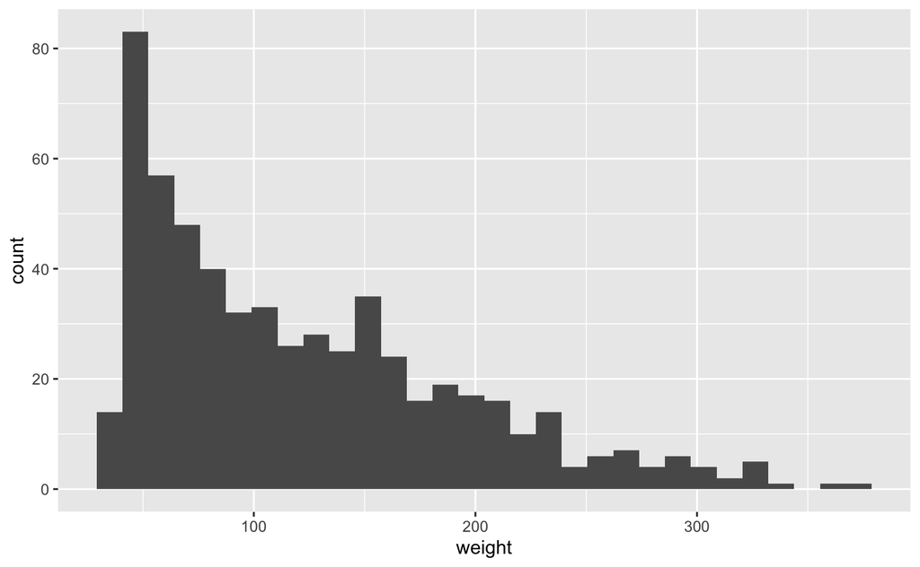

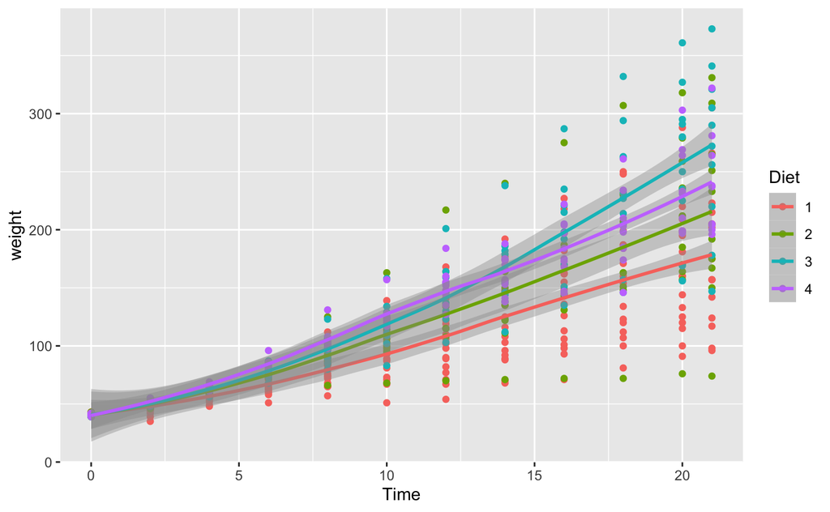

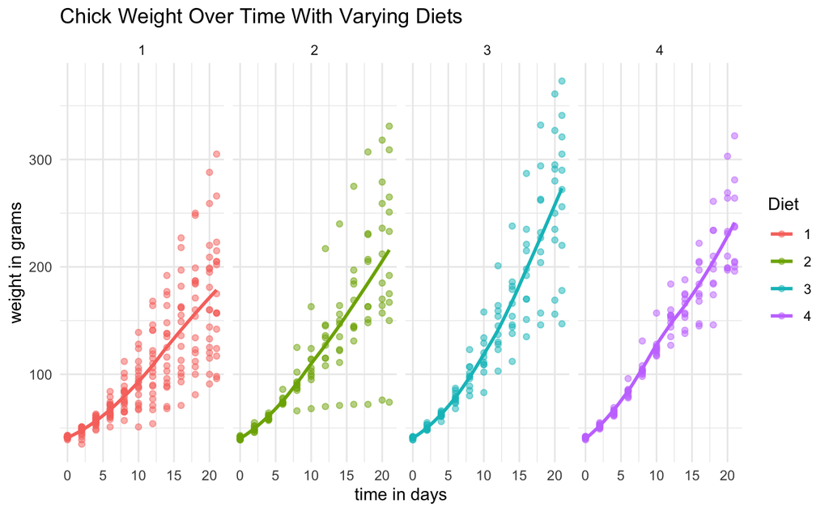

# ICMA Oct 7 2024

```
[1] NA
```

Based on your data, you must decide what you should do in this situation.

```
[1] 12
```

```
[1] "12.3"
```

3. logical TRUE or T FALSE or F stored as 1 and 0 resoectivly
4. Na 2 == Na && Na == Na both return Na bc R does not know what Na is.
5. and = && or || not = !

```
[1] TRUE
```

# ICMA Oct 9 2024

| id | age |
| --- | --- |
| 1 | 8 |
| 2 | 10 |
| 3 | 8 |
| 5 | 9 |

| id | gender |
| --- | --- |
| 1 | f |
| 2 | m |
| 3 | nb |
| 4 | m |
| 6 | f |

| id | age | gender |
| --- | --- | --- |
| 1 | 8 | f |
| 2 | 10 | m |
| 3 | 8 | nb |
| 5 | 9 | NA |
| 4 | NA | m |
| 6 | NA | f |

| id_x | gender | age |
| --- | --- | --- |
| 1 | f | 8 |
| 2 | m | 10 |
| 3 | nb | 8 |
| 4 | m | NA |
| 6 | f | NA |
| 5 | NA | 9 |

| id | age | gender |
| --- | --- | --- |
| 1 | 8 | f |
| 2 | 10 | m |
| 3 | 8 | nb |
| 5 | 9 | NA |
| 4 | NA | m |
| 6 | NA | f |

| id | age | gender |
| --- | --- | --- |
| 1 | 8 | f |
| 2 | 10 | m |
| 3 | 8 | nb |
| 4 | NA | m |
| 6 | NA | f |

| id | age | gender |
| --- | --- | --- |
| 1 | 8 | f |
| 2 | 10 | m |
| 3 | 8 | nb |
| 5 | 9 | NA |

| id | age | gender |
| --- | --- | --- |
| 1 | 8 | f |
| 2 | 10 | m |
| 3 | 8 | nb |

```
Error in `bind_cols()`:
! Can't recycle `..1` (size 5) to match `..2` (size 4).
Backtrace:
 1. dplyr::bind_cols(gender_data, age_data)
```

| id...1 | age | id...3 | gender |
| --- | --- | --- | --- |
| 1 | 8 | 1 | f |
| 2 | 10 | 2 | m |
| 3 | 8 | 3 | nb |
| 5 | 9 | 4 | m |

| id | age | gender |
| --- | --- | --- |
| 1 | 8 | NA |
| 2 | 10 | NA |
| 3 | 8 | NA |
| 5 | 9 | NA |
| 1 | NA | f |
| 2 | NA | m |
| 3 | NA | nb |
| 4 | NA | m |

# ICMA Oct 16 2024

Iteration: iterate over people

for(var in seq){ expr }

```
[1] "cat"
[1] "dog"
[1] "rabbit"
```

```
[1] "cat"
[1] "dog"
[1] "rabbit"
```

```
 [1] "MC" "AP" "NG" "VE" "AL" "AR" "MC" "RK" "AC" "SC" "KK" "RK" "VK" "MH"
 [1]  8  9 12  6 17  3  7  8  4 21 16 28 17 12
```

```
[1] "tbl_df"     "tbl"        "data.frame"
```

```
 [1]  8  9 12  6 17  3  7  8  4 21 16 28 17 12
```

```
[1] 8
[1] 9
[1] 12
[1] 6
[1] 17
[1] 3
[1] 7
[1] 8
[1] 4
[1] 21
[1] 16
[1] 28
[1] 17
[1] 12
```

```
[1] 14
```

```
[1] 8
[1] 9
[1] 12
[1] 6
[1] 17
[1] 3
[1] 7
[1] 8
[1] 4
[1] 21
[1] 16
[1] 28
[1] 17
[1] 12
```

```
[1] "MC's favorite number is 8"
[1] "AP's favorite number is 9"
[1] "NG's favorite number is 12"
[1] "VE's favorite number is 6"
[1] "AL's favorite number is 17"
[1] "AR's favorite number is 3"
[1] "MC's favorite number is 7"
[1] "RK's favorite number is 8"
[1] "AC's favorite number is 4"
[1] "SC's favorite number is 21"
[1] "KK's favorite number is 16"
[1] "RK's favorite number is 28"
[1] "VK's favorite number is 17"
[1] "MH's favorite number is 12"
```

# ICMA Oct 28 2024

Communicating data

Jargon: Dont use jargon that is not explained, try to stick to very well known acronyms like AI, or explain only what is necessary

Tell a story: Use analogies and metaphors

The power if three: Things are easuer to remember in 3s

Inroduction: Should have a big question or problem statemement. Literature review to motivate the problem statement Little quesion should be related to big questino but more small and manageable

Tell me what your gonna tell me, then tell me, then tell me again what you just told me

Zotero

# ICMA Oct 30 2024

setting r eval = FALSE makes code chunks not run

**writing in Bold**

*italics*

Part 2: create a variable, then write sentences w it

My name is Maanav and I don’t mind when people use both **bold** and *italics* in the same sentence.

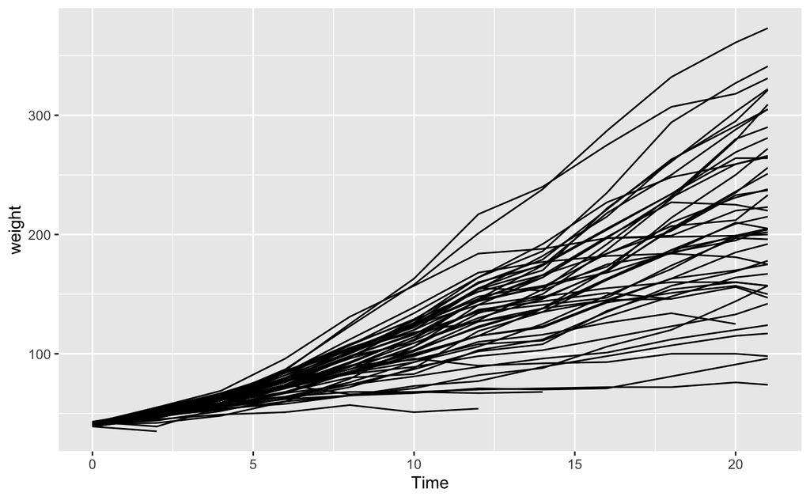

## ICMA Dec 2 2024

```
[1] "April" "Dec"   "Feb"   "Jan"   "March"
```

```
[1] "character"
```

```
[1] April Dec   Jan   Feb   March
Levels: Jan Feb March April Dec
```

```
[1] April Dec   Jan   Feb   March
Levels: Jan Feb March April May June July Dec
```

```
[1] April <NA>  Jan   Feb   March
Levels: Jan Feb March April May June July
```

because december is not in the levels, it designates it as an NA automatically, with no warning.

```
[1] April <NA>  Jan   Feb   March
Levels: Jan Feb March April May June July
```